# QC sdy998 data

Helen Miller

4/15/2020

# Load, prep, and QC data

This generally follows suggestions in https://osca.bioconductor.org/index.html.

```r
# This script will generally follow suggestions in https://osca.bioconductor.org/index.html.
suppressPackageStartupMessages({
  library(data.table)
  library(SingleCellExperiment)
})
```

## Reading in the data

This assumes that the single cell data from SDY998 has been downloaded into a `data` folder. It can be downloaded through aspera from https://browser.immport.org/browser?path=SDY998

```r
# Read it in and get in the correct format
if (!file.exists("data/celseq_matrix_ru10_molecules.tsv.725585")) {
  if (!file.exists("data/celseq_matrix_ru10_molecules.tsv.725585.gz")) {
    stop("can't find file!")
  }
  system("gunzip data/celseq_matrix_ru10_molecules.tsv.725585.gz")
}
umi_matrix <- data.table::fread("data/celseq_matrix_ru10_molecules.tsv.725585")
mat <- as.matrix(umi_matrix[,2:dim(umi_matrix)[2]])
mat[is.na(mat)] <- 0
rownames(mat) <- umi_matrix$gene
rm(umi_matrix)

sce <- SingleCellExperiment(assays = list(counts = mat))
```

## QC

NOTE: the CEL-seq protocol says that spike-ins were used, but I cannot find that data anywhere, so will not include that in QC.

It appears that emtpy wells have already been removed, but I’m not sure what the `Empty` celltype is.

https://osca.bioconductor.org/quality-control.html#choice-of-qc-metrics

### Derive per-cell QC metrics

Here’s how we could go about deriving QC metrics.

```r
# Derived meta -----
# Get metadata from annotationhub
library(AnnotationHub)
# ah <- AnnotationHub()
# grch37 <- subset(ah, genome == "GRCh37")
# grch37 <- grch37[["AH10684"]]
grch37 <- AnnotationHub()[["AH10684"]]
```

```
## snapshotDate(): 2019-10-29
```

```
## loading from cache
```

```r
# Get ranges by gene name
ranges <- range(split(grch37, ~gene_name))

# TODO
# There are a bunch of genes (134) which are missing from the ranges object...
# For now I'll just remove them so I can move on. Come fix this later!
sce <- sce[rownames(sce) %in% names(ranges),]
rowRanges(sce) <- ranges[rownames(sce)]

# Get percent mitochondrial dna
is.mito <- any(seqnames(rowRanges(sce))=="MT")

library(scater)
df <- perCellQCMetrics(sce, subsets=list(Mito=is.mito))
# sce <- addPerCellQC(sce, subsets=list(Mito=is.mito))
```

## Use provided QC metrics

QC metric per cell were provided, so we will use those.

```r
cell_meta <- fread("data/celseq_meta.tsv.725591.gz")
# rownames(cell_meta) <- cell_meta$cell_name
# colData(sce) <- cell_meta
```

## Remove low-quality cells

https://osca.bioconductor.org/quality-control.html#quality-control-outlier

### QC by batch

This data should be qc’d by batch, as it includes data from multiple donors, and has been sorted by cell-type. I’m not sure if we should also batch it based on plate.

```r
cell_meta[, batch := paste0(sample, type)]
qc.mol <- isOutlier(cell_meta$molecules, log=TRUE, type="lower", batch = cell_meta$batch)
qc.nexprs <- isOutlier(cell_meta$genes_detected, log=TRUE, type="lower", batch = cell_meta$batch)
qc.mito <- isOutlier(cell_meta$percent_mt_molecules, type="higher", batch = cell_meta$batch)
discard <- qc.mol | qc.nexprs | qc.mito
DataFrame(LibSize=sum(qc.mol), NExprs=sum(qc.nexprs),
          MitoProp=sum(qc.mito), Total=sum(discard))
```

```
## DataFrame with 1 row and 4 columns
##     LibSize    NExprs  MitoProp     Total
##   <integer> <integer> <integer> <integer>
## 1       357       500       764       894
```

### Diagnostic plots

https://osca.bioconductor.org/quality-control.html#quality-control-plots

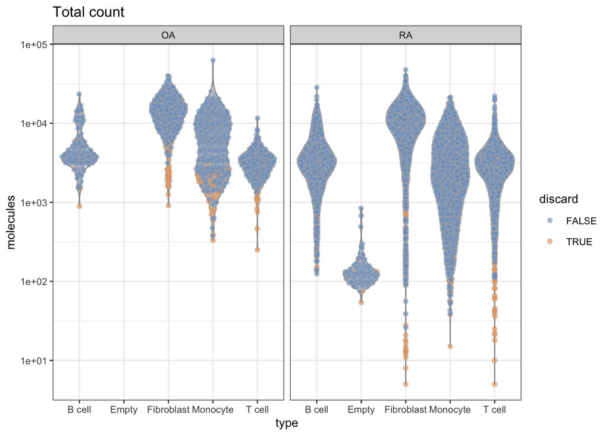

```r
colData(sce) <- DataFrame(cell_meta)
sce$discard <- discard
plotColData(sce, x = "type", y = "molecules", colour_by = "discard", other_fields = "disease") +
  facet_wrap(~disease) +
  scale_y_log10() + ggtitle("Total count")
```

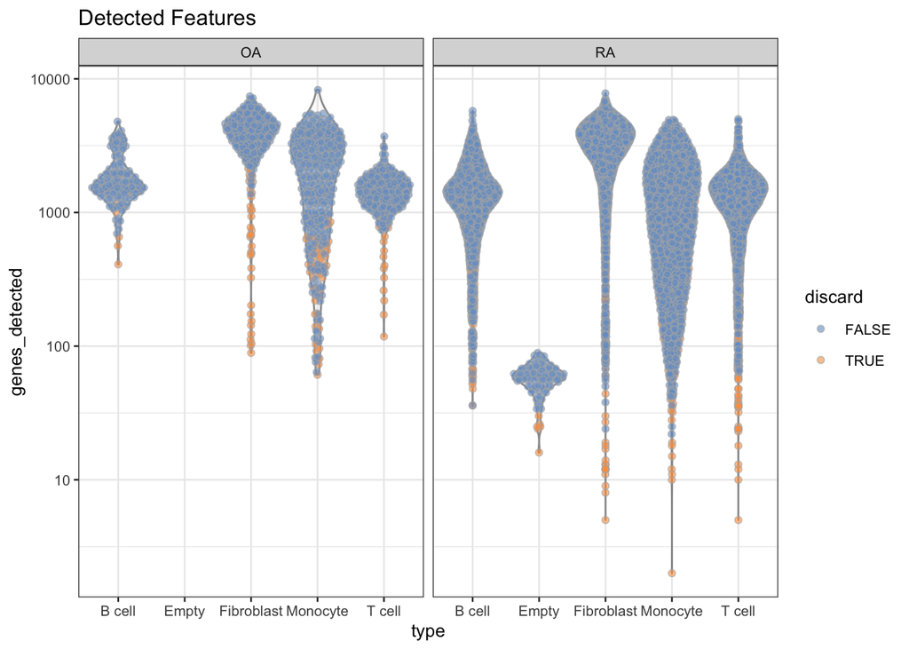

```r
plotColData(sce, x = "type", y = "genes_detected", colour_by = "discard", other_fields = "disease") +
  facet_wrap(~disease) +
  scale_y_log10() + ggtitle("Detected Features")
```

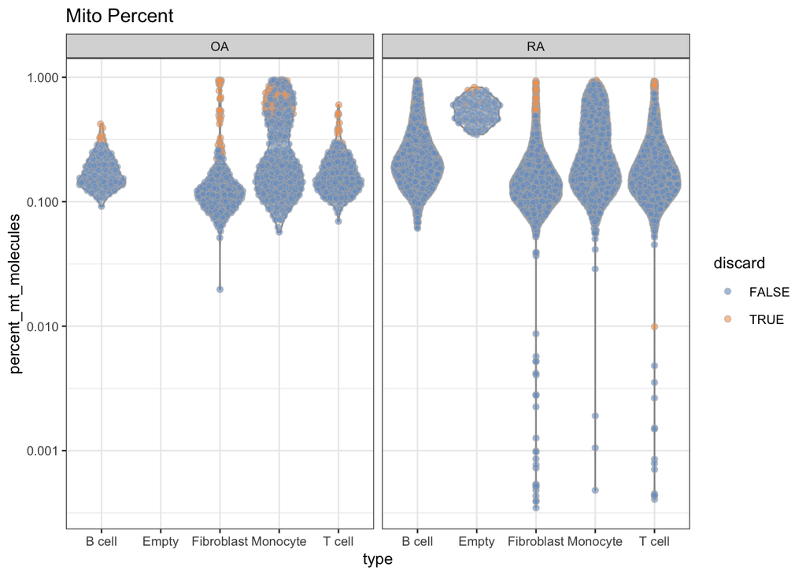

```r
plotColData(sce, x = "type", y = "percent_mt_molecules", colour_by = "discard", other_fields = "disease") +
  facet_wrap(~disease) +
  scale_y_log10() + ggtitle("Mito Percent")
```

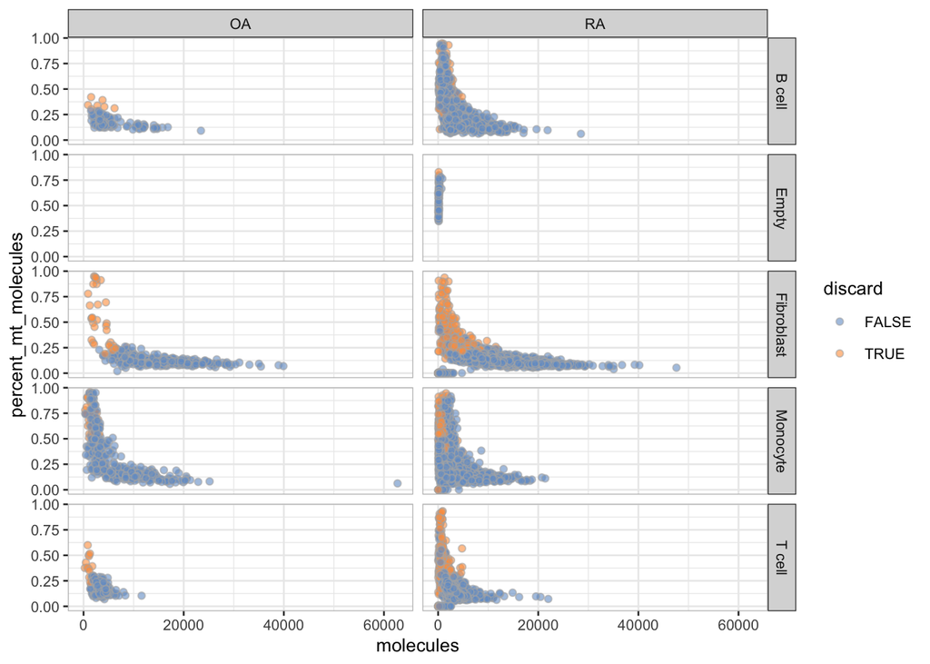

```r
plotColData(sce, x="molecules", y="percent_mt_molecules",
            colour_by="discard", other_fields=c("disease", "type")) +
  facet_grid(type~disease) +
  theme(panel.border = element_rect(color = "grey"))
```

### Cell calling

https://osca.bioconductor.org/quality-control.html#qc-droplets

Not running this because I think it has already been done.

### Diagnose cell-type loss

https://osca.bioconductor.org/quality-control.html#quality-control-discarded

Check to make sure that you haven’t removed cells that were outliers because of actual biological differences.

```r
discard <- sce$discard
filtered <- sce[, !discard]
lost <- calculateAverage(counts(sce)[,!discard])
kept <- calculateAverage(counts(sce)[,discard])
library(edgeR)
```

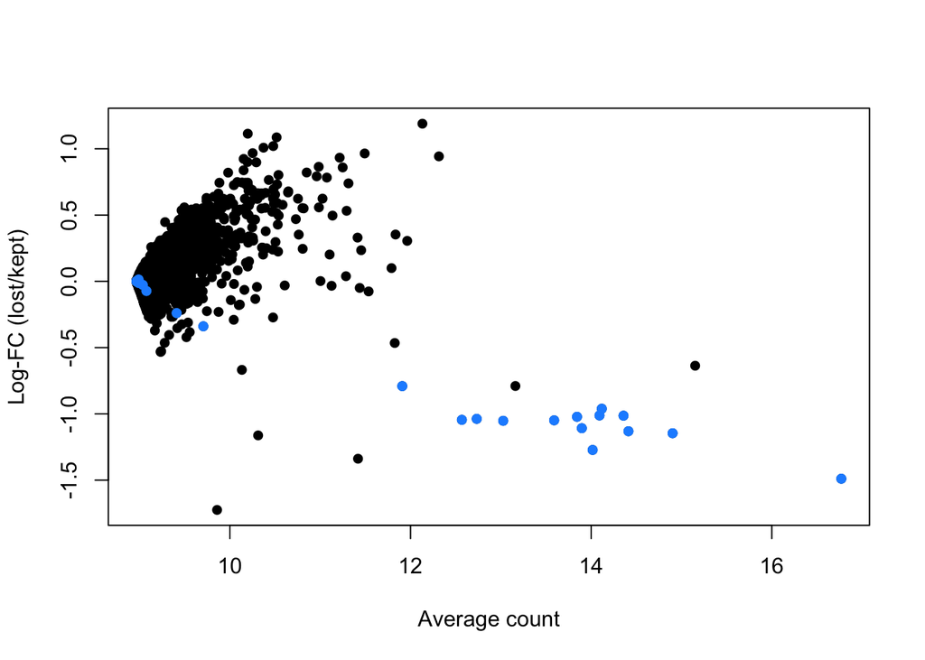

```r
logged <- cpm(cbind(lost, kept), log=TRUE, prior.count=2)
logFC <- logged[,1] - logged[,2]
abundance <- rowMeans(logged)
plot(abundance, logFC, xlab="Average count", ylab="Log-FC (lost/kept)", pch=16)
points(abundance[is.mito], logFC[is.mito], col="dodgerblue", pch=16)
points(abundance[is.mito], logFC[is.mito], col="dodgerblue", pch=16)
```

### Mark or filter bad cells

https://osca.bioconductor.org/quality-control.html#marking-qc

At this point, we have the option to move forward with either the filtered version of the data, or just mark cells that should be filtered. As suggested, we will save the filtered version for future analysis.

```r
saveRDS(filtered, "data/sceQC.rds")
```